# Analyzing Loan Data - Prosper Funding LLC

Aritra Chattaraj

January 26, 2019

========================================================

## Introduction - Prosper

Prosper Marketplace, Inc. is a San Francisco, California-based company in the peer-to-peer lending industry. Prosper Funding LLC, one of its subsidiaries, operates Prosper.com, a website where individuals can either invest in personal loans or request to borrow money.

Prosper Marketplace is America’s first peer-to-peer lending marketplace, with over $7 billion in funded loans. Borrowers request personal loans on Prosper and investors (individual or institutional) can fund anywhere from $2,000 to $35,000 per loan request. Investors can consider borrowers’ credit scores, ratings, and histories and the category of the loan. Prosper handles the servicing of the loan and collects and distributes borrower payments and interest back to the loan investors.

Prosper verifies borrowers’ identities and select personal data before funding loans and manages all stages of loan servicing. Prosper’s unsecured personal loans are fully amortized over a period of three or five years, with no pre-payment penalties. Prosper generates revenue by collecting a one-time fee on funded loans from borrowers and assessing an annual loan servicing fee to investors.

Prosper has provided an increasing amount of information about prospective borrowers over time, while also making various changes to its credit policy. Prior to its 2008 ‘quiet period’ and 2009 SEC registration, the company provided “Credit Grades” and other credit information about its prospective lenders. Following the SEC registration, the company created a new model that determined “Prosper Ratings” instead. Additionally, new prospective borrowers were required to have an FICO 8 credit score of at least 640, while returning borrowers only need a score of 600 to request a loan.

## Project Brief

This project analyzes about 114,000 observations and 12 of the 81 variables in this data set. The data set contains information of about 114,000 individuals (anonymized, of course) across 81 parameters.

There are three major sections in this project, each providing a piece for the final assessment. These sections are - Univariate Analysis, Bivariate Analysis and Multivariate Analysis. At the end, the final summary explains the results of our analyses.

## Variables of Interest

The 12 variables of interest chosen out of the 81, for the purpose of this project, are: **LoanStatus, ProsperScore, BorrowerAPR, BorrowerRate, EmploymentStatus, Occupation, EmploymentStatusDuration, IsBorrowerHomeowner, StatedMonthlyIncome, MonthlyLoanPayment, DebtToIncomeRatio, LoanOriginalAmount.**

```
## # A tibble: 10 x 81
##    ListingKey ListingNumber ListingCreationDate CreditGrade  Term
##    <chr>              <dbl> <dttm>              <chr>       <dbl>
##  1 102133976~        193129 2007-08-26 19:09:29 C              36
##  2 102736024~       1209647 2014-02-27 08:28:07 <NA>           36
##  3 0EE933782~         81716 2007-01-05 15:00:47 HR             36
##  4 0EF535600~        658116 2012-10-22 11:02:35 <NA>           36
##  5 0F0235894~        909464 2013-09-14 18:38:39 <NA>           36
##  6 0F0535973~       1074836 2013-12-14 08:26:37 <NA>           60
##  7 0F0A35767~        750899 2013-04-12 09:52:56 <NA>           36
##  8 0F1035772~        768193 2013-05-05 06:49:27 <NA>           36
##  9 0F0435962~       1023355 2013-12-02 10:43:39 <NA>           36
## 10 0F0435962~       1023355 2013-12-02 10:43:39 <NA>           36
## # ... with 76 more variables: LoanStatus <chr>, ClosedDate <dttm>,
## #   BorrowerAPR <dbl>, BorrowerRate <dbl>, LenderYield <dbl>,
## #   EstimatedEffectiveYield <dbl>, EstimatedLoss <dbl>,
## #   EstimatedReturn <dbl>, `ProsperRating (numeric)` <dbl>, `ProsperRating
## #   (Alpha)` <chr>, ProsperScore <dbl>, `ListingCategory (numeric)` <dbl>,
## #   BorrowerState <chr>, Occupation <chr>, EmploymentStatus <chr>,
## #   EmploymentStatusDuration <dbl>, IsBorrowerHomeowner <lgl>,
## #   CurrentlyInGroup <lgl>, GroupKey <chr>, DateCreditPulled <dttm>,
## #   CreditScoreRangeLower <dbl>, CreditScoreRangeUpper <dbl>,
## #   FirstRecordedCreditLine <dttm>, CurrentCreditLines <dbl>,
## #   OpenCreditLines <dbl>, TotalCreditLinespast7years <dbl>,
## #   OpenRevolvingAccounts <dbl>, OpenRevolvingMonthlyPayment <dbl>,
## #   InquiriesLast6Months <dbl>, TotalInquiries <dbl>,
## #   CurrentDelinquencies <dbl>, AmountDelinquent <dbl>,
## #   DelinquenciesLast7Years <dbl>, PublicRecordsLast10Years <dbl>,
## #   PublicRecordsLast12Months <dbl>, RevolvingCreditBalance <dbl>,
## #   BankcardUtilization <dbl>, AvailableBankcardCredit <dbl>,
## #   TotalTrades <dbl>, `TradesNeverDelinquent (percentage)` <dbl>,
## #   TradesOpenedLast6Months <dbl>, DebtToIncomeRatio <dbl>,
## #   IncomeRange <chr>, IncomeVerifiable <lgl>, StatedMonthlyIncome <dbl>,
## #   LoanKey <chr>, TotalProsperLoans <dbl>,
## #   TotalProsperPaymentsBilled <dbl>, OnTimeProsperPayments <dbl>,
## #   ProsperPaymentsLessThanOneMonthLate <dbl>,
## #   ProsperPaymentsOneMonthPlusLate <dbl>, ProsperPrincipalBorrowed <dbl>,
## #   ProsperPrincipalOutstanding <dbl>, ScorexChangeAtTimeOfListing <dbl>,
## #   LoanCurrentDaysDelinquent <dbl>, LoanFirstDefaultedCycleNumber <dbl>,
## #   LoanMonthsSinceOrigination <dbl>, LoanNumber <dbl>,
## #   LoanOriginalAmount <dbl>, LoanOriginationDate <dttm>,
## #   LoanOriginationQuarter <chr>, MemberKey <chr>,
## #   MonthlyLoanPayment <dbl>, LP_CustomerPayments <dbl>,
## #   LP_CustomerPrincipalPayments <dbl>, LP_InterestandFees <dbl>,
## #   LP_ServiceFees <dbl>, LP_CollectionFees <dbl>,
## #   LP_GrossPrincipalLoss <dbl>, LP_NetPrincipalLoss <dbl>,
## #   LP_NonPrincipalRecoverypayments <dbl>, PercentFunded <dbl>,
## #   Recommendations <dbl>, InvestmentFromFriendsCount <dbl>,
## #   InvestmentFromFriendsAmount <dbl>, Investors <dbl>
```

## Univariate Plots Section

This section explores univariate characteristics in our data through multiple univariate plots.

The dataset is first subsetted to include only the 12 variables of importance prior to any further analysis/plots.

### **Subsetting the data**

```
## # A tibble: 20 x 12
##    LoanStatus ProsperScore BorrowerAPR BorrowerRate EmploymentStatus
##    <chr>             <dbl>       <dbl>        <dbl> <chr>
##  1 Completed            NA      0.165        0.158  Self-employed
##  2 Current               7      0.120        0.092  Employed
##  3 Completed            NA      0.283        0.275  Not available
##  4 Current               9      0.125        0.0974 Employed
##  5 Current               4      0.246        0.208  Employed
##  6 Current              10      0.154        0.131  Employed
##  7 Current               2      0.310        0.271  Employed
##  8 Current               4      0.239        0.202  Employed
##  9 Current               9      0.0762       0.0629 Employed
## 10 Current              11      0.0762       0.0629 Employed
## 11 Current               7      0.275        0.249  Employed
## 12 Completed            NA      0.150        0.132  Full-time
## 13 Past Due ~            4      0.180        0.144  Employed
## 14 Current               8      0.131        0.103  Employed
## 15 Current               8      0.117        0.0949 Employed
## 16 Defaulted             5      0.358        0.318  Other
## 17 Current               4      0.307        0.281  Full-time
## 18 Chargedoff           NA      0.132        0.125  Not available
## 19 Current               7      0.125        0.0974 Employed
## 20 Current               8      0.248        0.222  Employed
## # ... with 7 more variables: Occupation <chr>,
## #   EmploymentStatusDuration <dbl>, IsBorrowerHomeowner <lgl>,
## #   StatedMonthlyIncome <dbl>, MonthlyLoanPayment <dbl>,
## #   DebtToIncomeRatio <dbl>, LoanOriginalAmount <dbl>
```

The data has been successfully subsetted and contains all the observations and only the seleted 12 variables.

#### **Summary of Data**

Prior to some plots, let us check out the characteristics of the chosen variables in our data subset.

```
##   LoanStatus         ProsperScore    BorrowerAPR       BorrowerRate
##  Length:113937      Min.   : 1.00   Min.   :0.00653   Min.   :0.0000
##  Class :character   1st Qu.: 4.00   1st Qu.:0.15629   1st Qu.:0.1340
##  Mode  :character   Median : 6.00   Median :0.20976   Median :0.1840
##                     Mean   : 5.95   Mean   :0.21883   Mean   :0.1928
##                     3rd Qu.: 8.00   3rd Qu.:0.28381   3rd Qu.:0.2500
##                     Max.   :11.00   Max.   :0.51229   Max.   :0.4975
##                     NA's   :29084   NA's   :25
##  EmploymentStatus    Occupation        EmploymentStatusDuration
##  Length:113937      Length:113937      Min.   :  0.00
##  Class :character   Class :character   1st Qu.: 26.00
##  Mode  :character   Mode  :character   Median : 67.00
##                                        Mean   : 96.07
##                                        3rd Qu.:137.00
##                                        Max.   :755.00
##                                        NA's   :7625
##  IsBorrowerHomeowner StatedMonthlyIncome MonthlyLoanPayment
##  Mode :logical       Min.   :      0     Min.   :   0.0
##  FALSE:56459         1st Qu.:   3200     1st Qu.: 131.6
##  TRUE :57478         Median :   4667     Median : 217.7
##                      Mean   :   5608     Mean   : 272.5
##                      3rd Qu.:   6825     3rd Qu.: 371.6
##                      Max.   :1750003     Max.   :2251.5
##
##  DebtToIncomeRatio LoanOriginalAmount
##  Min.   : 0.000    Min.   : 1000
##  1st Qu.: 0.140    1st Qu.: 4000
##  Median : 0.220    Median : 6500
##  Mean   : 0.276    Mean   : 8337
##  3rd Qu.: 0.320    3rd Qu.:12000
##  Max.   :10.010    Max.   :35000
##  NA's   :8554
```

The summary reveals a number of interesting points about our data - there are 8 numerical variables (ProsperScore, BorrowerAPR, BorrowerRate, EmploymentStatusDuration, StatedMonthlyIncome, MonthlyLoanPayment, DebtToIncomeRatio, LoanOriginalAmount); there are 3 categorical variables (LoanStatus, Occupation, EmploymentStatus); there is 1 logical (dichotomous i.e. Y/N or True/False in this case) variable (IsBorrowerHomeowner).

There are a number of missing or NaN variables with the highest number being 29084 (ProsperScore) and lowest non-zero being 25 (BorrowerAPR). This is something to keep in mind to decide whether we want to omit the observations or impute them and what best method for imputation should be chosen at the time of modeling.

A number of other observations in the summary is, perhaps, better explained through the following plots.

### Plots - Univariate

#### Univariate Plot 1 - ProsperScore

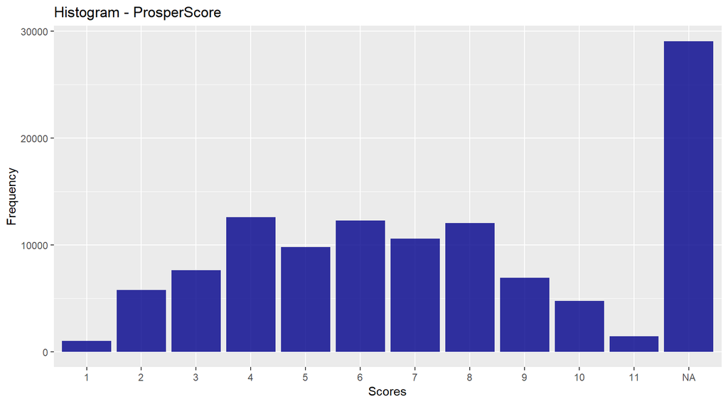

The histogram reveals a trend in the ProsperScore where the mean is centered around 4-8 on the scale. Most of the observations or individuals have a Prosper Score in the brackets of 4, 6 or 8 and the data is normally distributed with a slight right-skew and leptokurtic tendency.

#### Univariate Plot 2 - BorrowerAPR

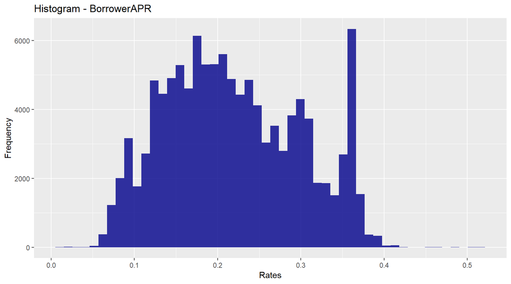

The BorrowerAPR reveals an almost normally distributed characteristic with an unusually large number of observations between 0.3 - 0.4 (almost like a bimodal distribution). The data is definitely right skewed and leptokurtic.

#### Univariate Plot 3 - BorrowerRate

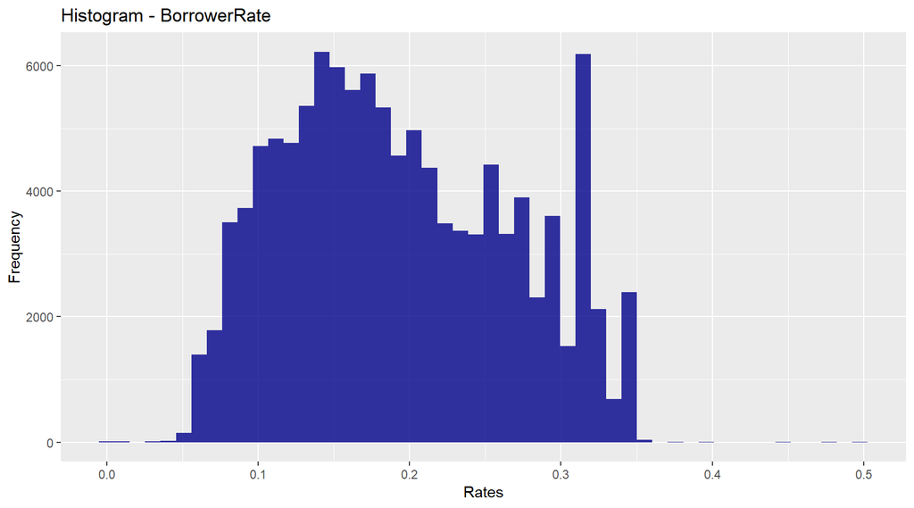

BorrowerRate exhibits very similar characteristics as our BorrowerAPR.

#### Univariate Plot 4 - EmploymentStatusDuration

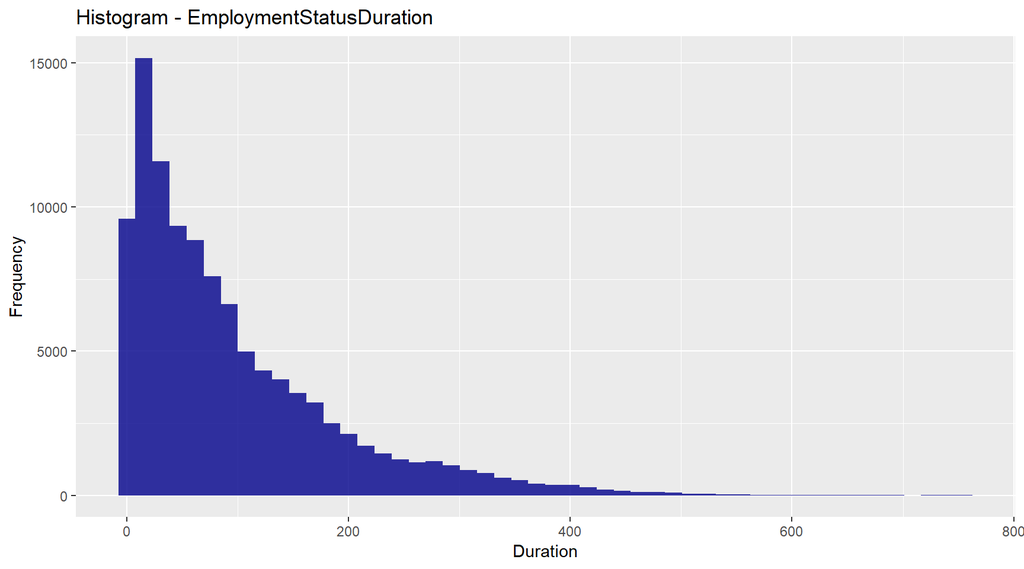

Employment Status Duration represents a power-law distribution of the data which is heavily right-skewed. This implies that a large number of Prosper customers have an employment duration of 2-3 years whereas there are outliers such as 44 years and more.

#### Univariate Plot 5 - StatedMonthlyIncome (Limited to $50,000 per month)

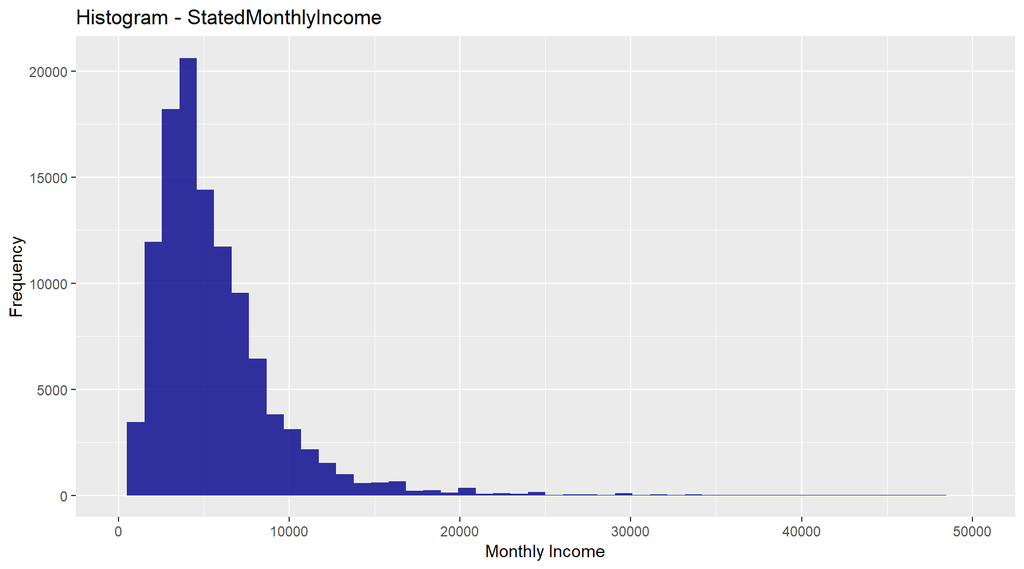

Shows a power-law distribution with a heavy right-skew. Majority of the income earners make about $4,000 - $6,000 a month.

#### Univariate Plot 6 - MonthlyLoanPayment

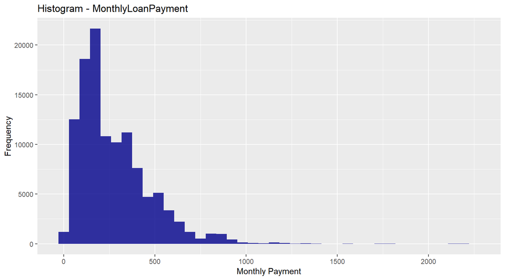

Shows a power-law distribution with a heavy right-skew, similar to our last plot. Majority of the monthly payments are in the range $150 - $250.

#### Univariate Plot 7 - DebtToIncomeRatio

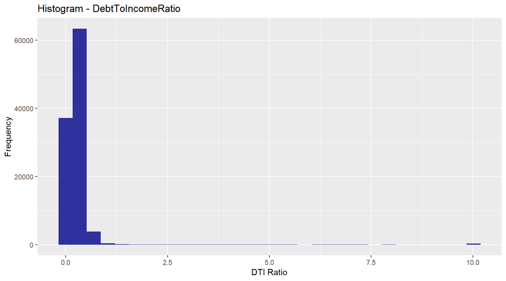

#### Univariate Plot 8 - LoanOriginalAmount

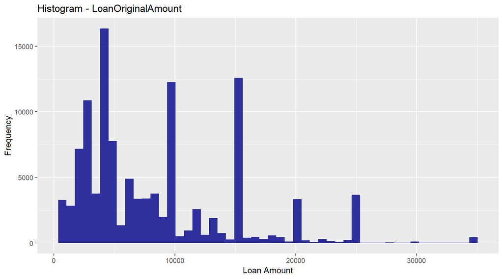

#### Univariate Plot 9 - LoanStatus

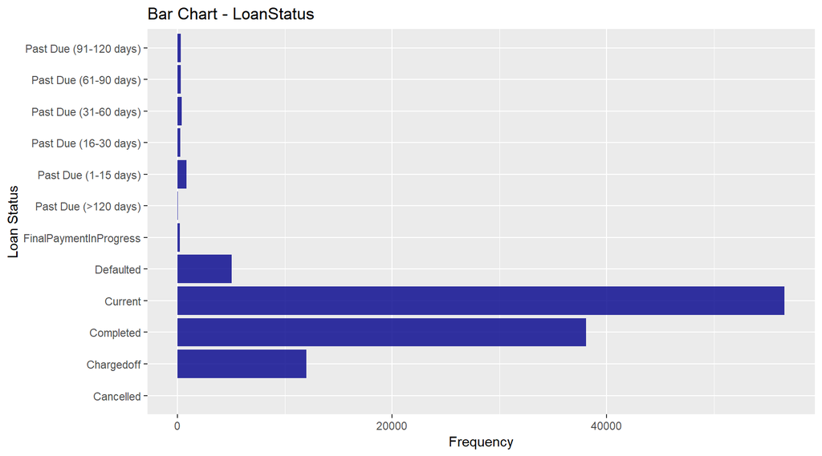

This is the first of the categorical variables of interest to be visualized - what we can see right off the bat is the frequency of people whose loan status is ‘Current’ as they form the majority of the observations in our data. We can ascertain that most of the people are either currently indebted (‘Current’) or have paid off their loan (‘Completed’) or have been ‘Chargedoff’ or they have defaulted on their loan (‘Defaulted’). These 4 are our primary labels of interest while we’re investigating ‘LoanStatus’ variable.

#### Univariate Plot 10 - Occupation

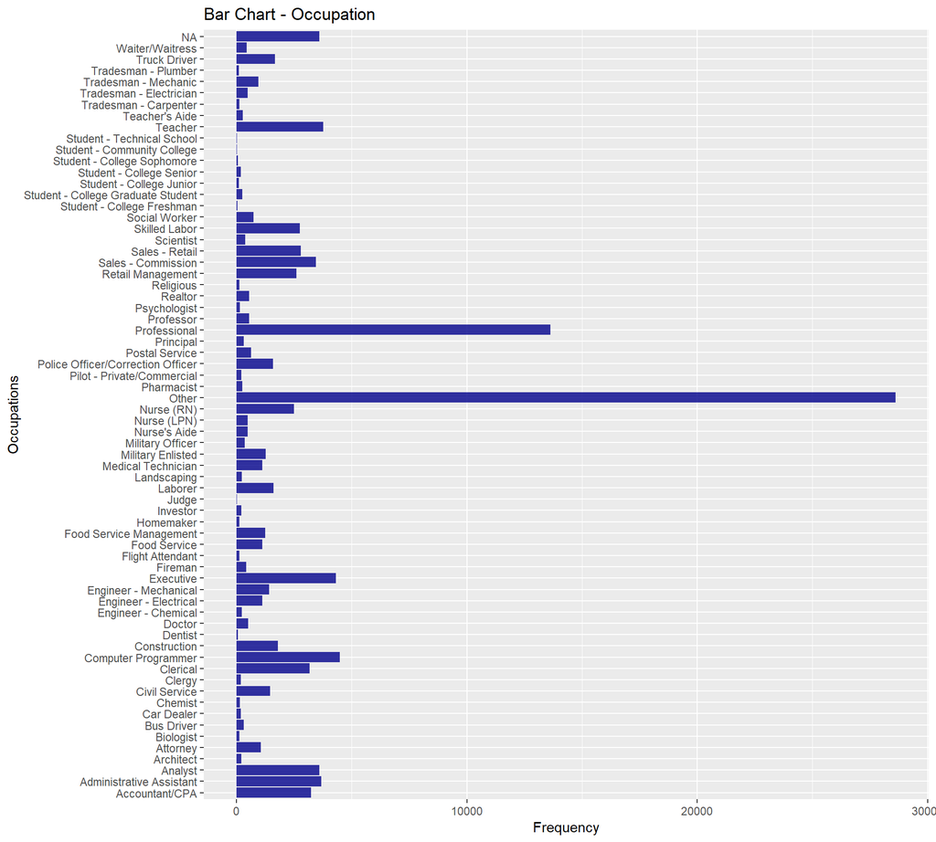

Interestingly enough a vast majority of the observations identify themselves with the “Others” occupation whereas the second-highest majority identity with “Professional.”

#### Univariate Plot 11 - EmploymentStatus

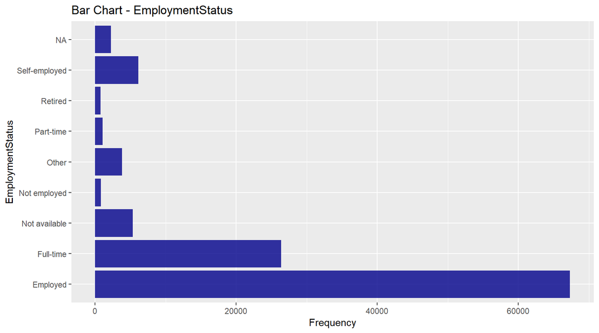

#### Univariate Plot 12 - IsBorrowerHomeowner

[figure not shown]

The number of homeowners versus the number of non-homeowners are almost the same wherein the homeowners are slightly more.

## Univariate Analysis

### What is the structure of your dataset?

This dataset is of the dimension 113937x81 out of the which the focus has been on a subset of dimension 113937x12. The data was also in a tidy format at the outset, therefore, there was no need for formatting it any further prior to analyses.

### What is/are the main feature(s) of interest in your dataset?

I have picked 12 variables to explore in this project. The two variables that are of my primary interest are ProsperScore and LoanStatus.

### Did you create any new variables from existing variables in the dataset?

No, I did not perform any kind of feature engineering for the purpose of this exploratory project. That kind of requirement just never popped up so far.

### Of the features you investigated, were there any unusual distributions? Did you perform any operations on the data to tidy, adjust, or change the form of the data? If so, why did you do this?

The data was already in a tidy format. As far as distributions are concerned, I’ve made a comment on the characteristics of the distributions which I arrived to via histograms after each plot. For the categorical variables, I had to flip the x and y axes to ensure better readability of the labels and their corresponding frequencies.

Some of the variables were almost normally distributed, some followed a power-law distribution - by and large, I’ve made an effort to note that down alongside the aforementioned plots.

## Bivariate Plots Section

#### Summary

At this juncture, to further examine our variables of interest, we proceed with some bivariate plots. These plots will help us figure out the relationship between variables that are coupled together.

### Plots - Bivariate

We’ll first explore bivariate plots with our first variable of interest - ProsperScore.

#### Bivariate Plot 1 - ProsperScore and BorrowerRate

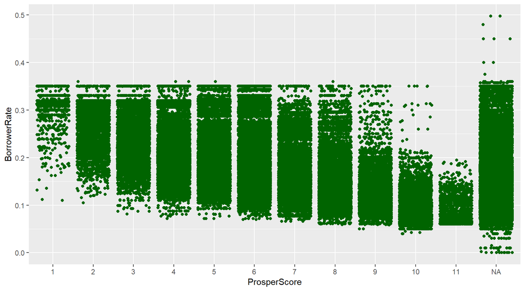

#### Bivariate Plot 2 - ProsperScore and BorrowerAPR

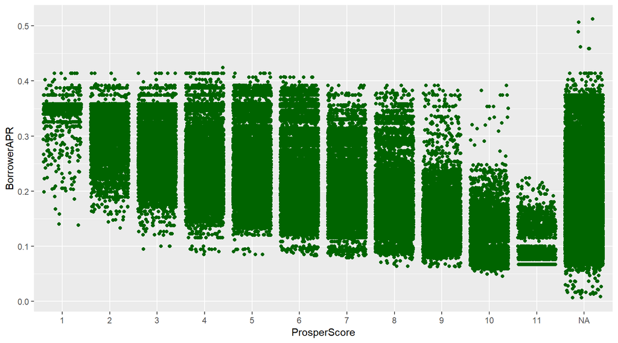

#### Bivariate Plot 3 - MonthlyLoanPayment and Occupation

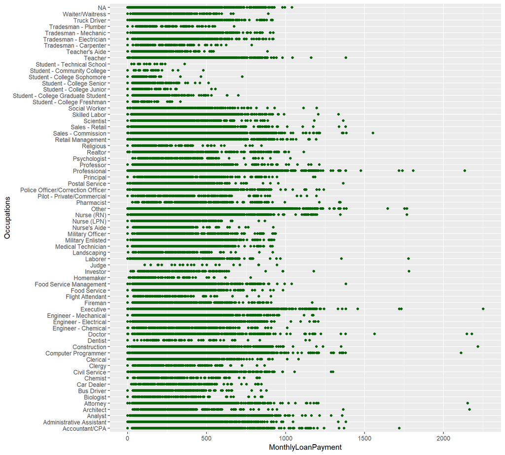

#### Bivariate Plot 4 - ProsperScore and LoanStatus

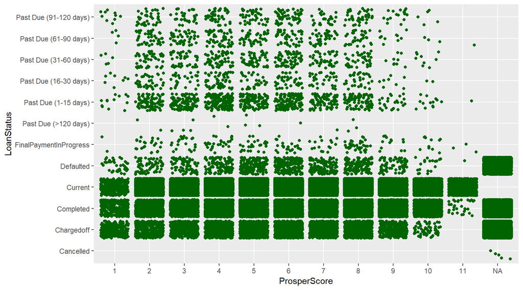

#### Bivariate Plot 5 - ProsperScore and IsBorrowerHomeowner

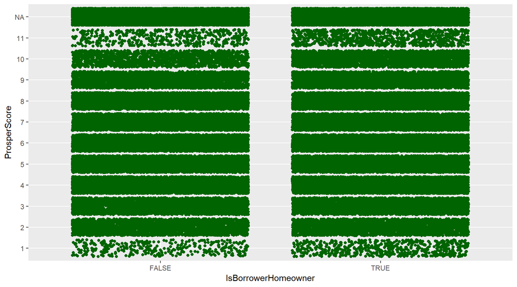

#### Bivariate Plot 6 - ProsperScore and EmploymentStatus

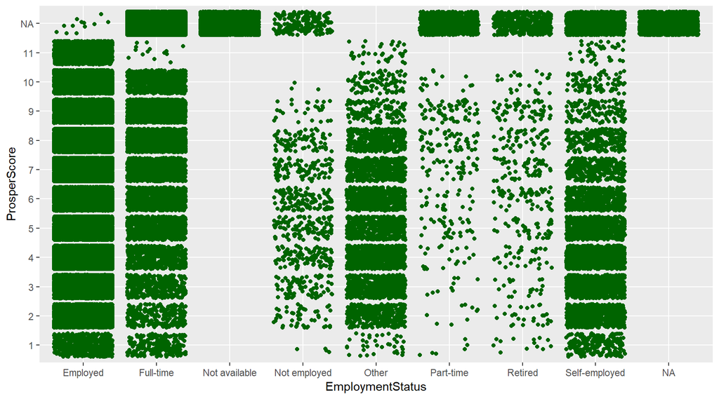

#### Bivariate Plot 7 - ProsperScore and LoanOriginalAmount

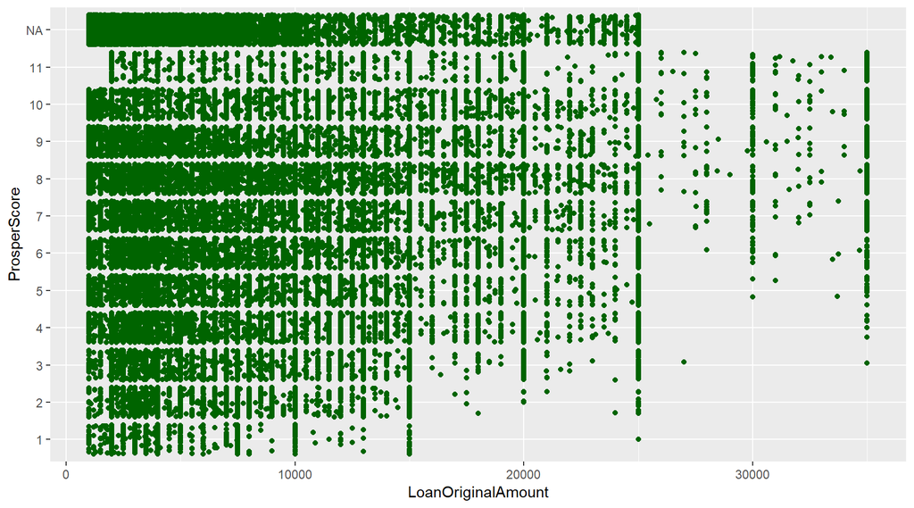

#### Bivariate Plot 8 - ProsperScore and MonthlyLoanPayment

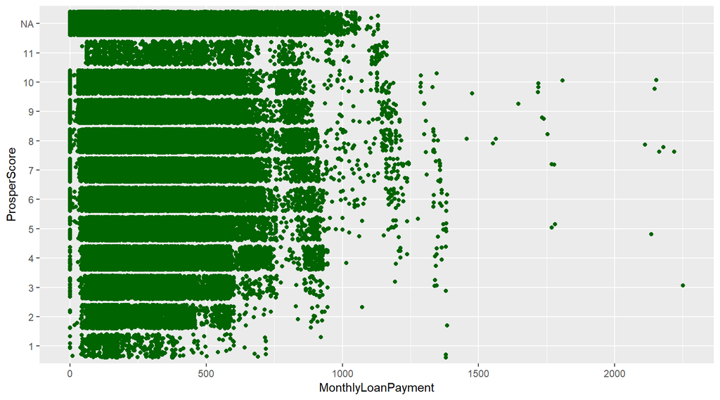

#### Bivariate Plot 9 - ProsperScore and StatedMonthlyIncome

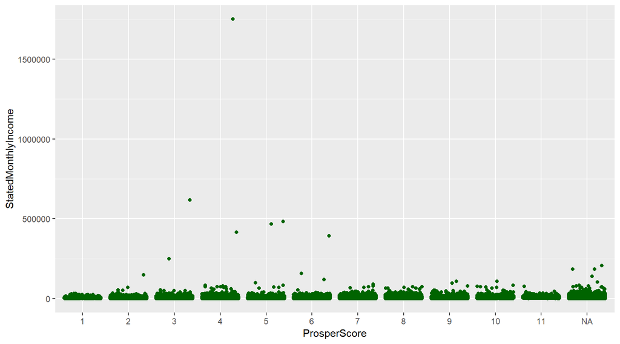

> We’ll now explore more bivariate plots with our second variable of interest - LoanStatus

#### Bivariate Plot 10 - LoanStatus and IsBorrowerHomeowner

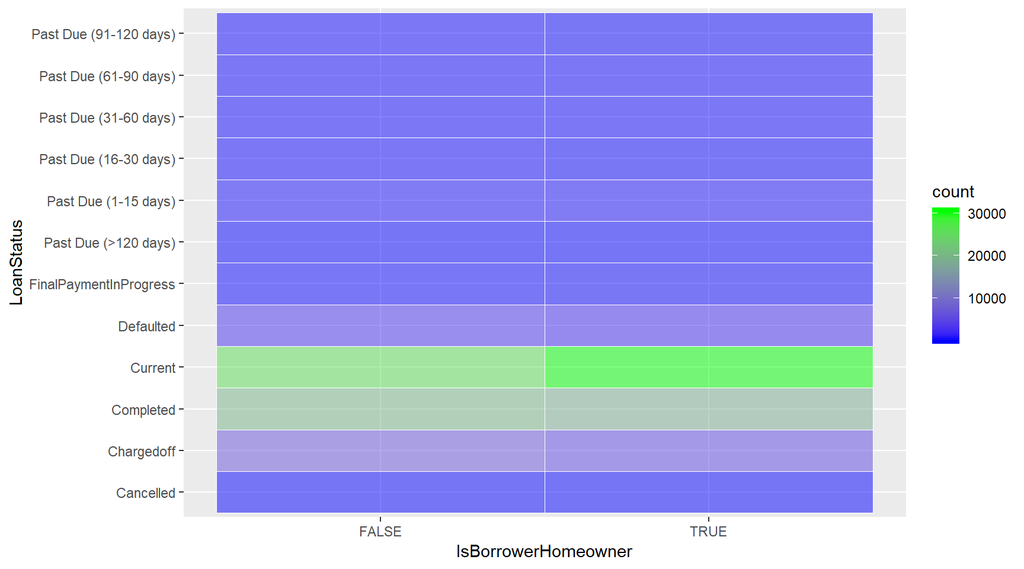

#### Bivariate Plot 11 - LoanStatus and EmploymentStatus

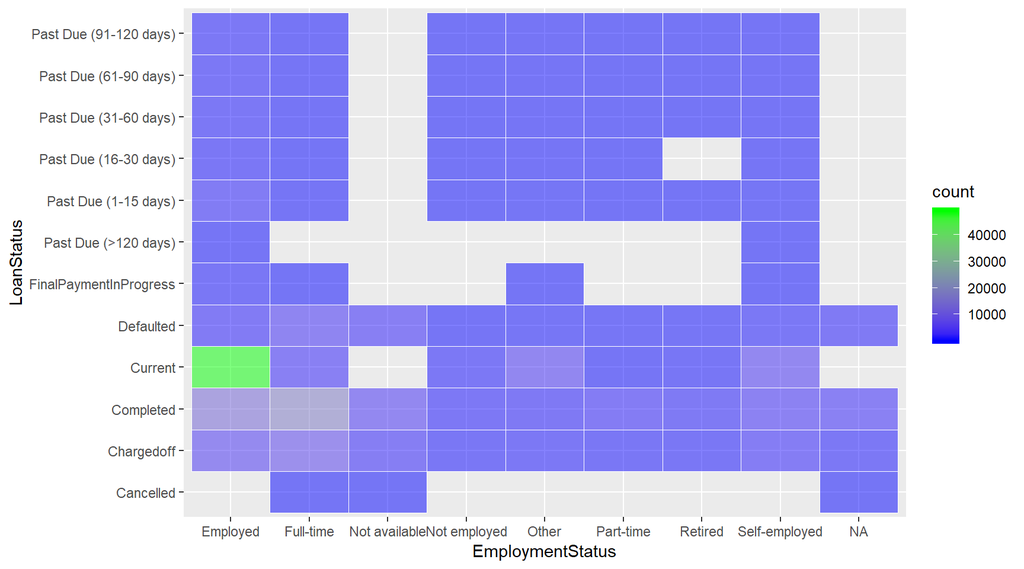

#### Bivariate Plot 12 - LoanStatus and Occupation

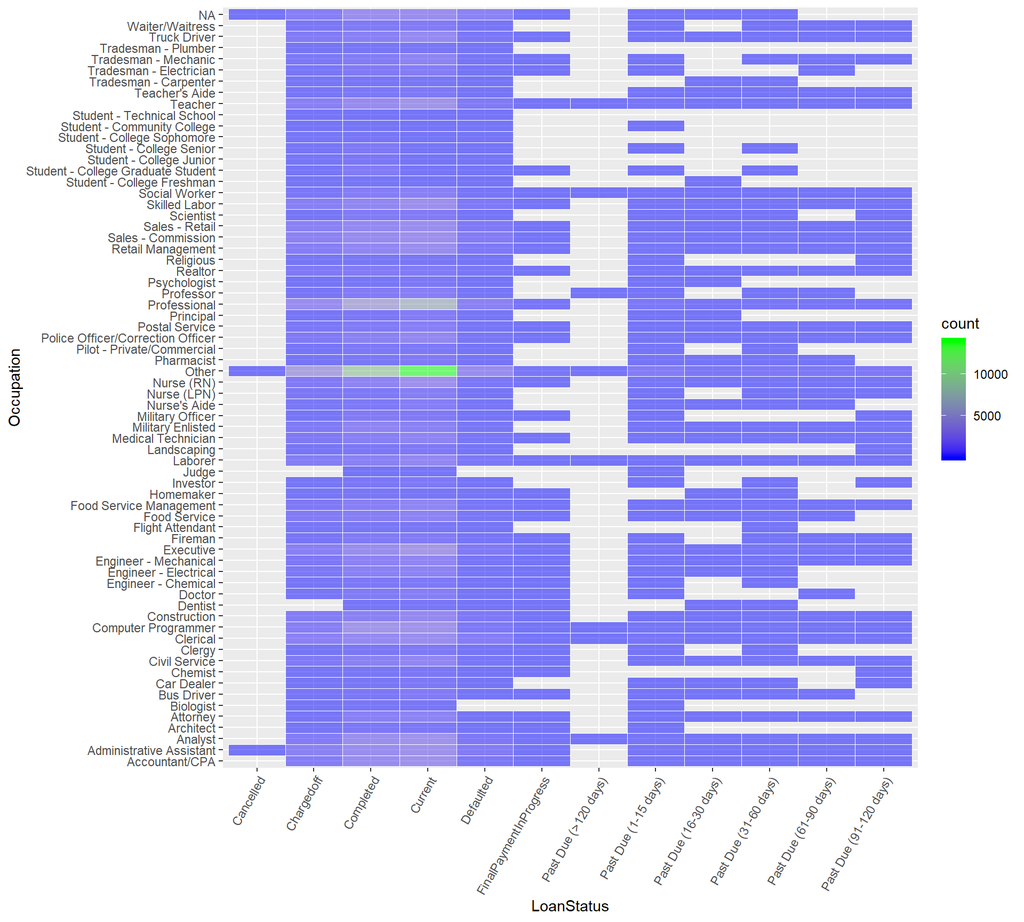

#### Bivariate Plot 13 - LoanStatus and LoanOriginalAmount

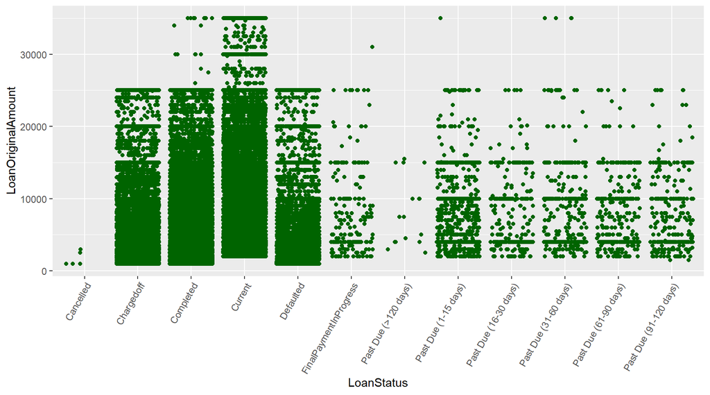

#### Bivariate Plot 14 - LoanStatus and StatedMonthlyIncome

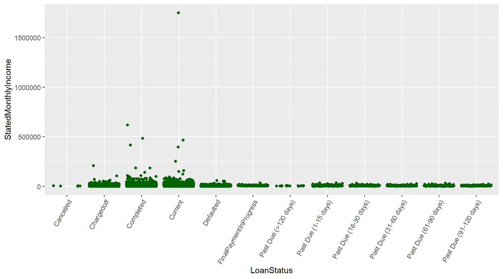

#### Bivariate Plot 15 - LoanStatus and EmploymentStatusDuration

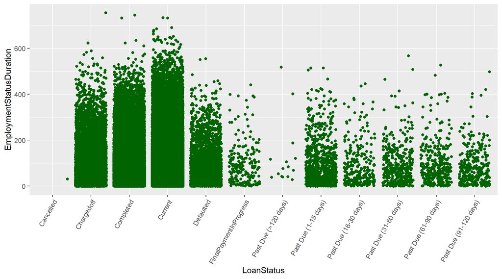

#### Bivariate Plot 16 - LoanStatus and BorrowerRate

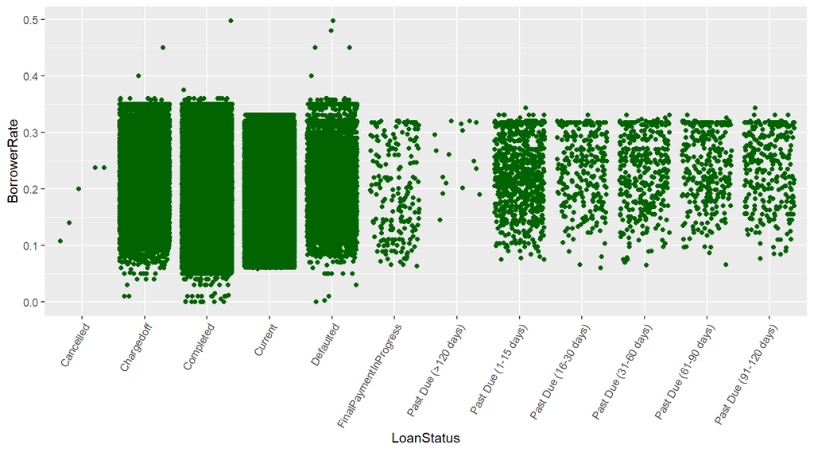

## Bivariate Analysis

### Talk about some of the relationships you observed in this part of the investigation. How did the feature(s) of interest vary with other features in the dataset?

The main relationships explored in this section are the ProsperScore and LoanStatus relationships with other variables of import.

ProsperScore and BorrowerRate are clearly correlated. It can be observed that the higher the average ProsperScore, the lower the BorrowerRate.

The same property applies when we discuss BorrowerAPR and ProsperScore. Since BorrowerAPR and BorrowerRate are firstly correlated, it only follows that the ProsperScore versus BorrowerAPR will also show similar properties. However, our graphs show that for BorrowerAPR, the highest rate is around 0.41 whereas it is 0.35 for BorrowerRate for the same set of observations.

ProsperScore seems to be better for Employed people as opposed to other Employment statuses but that’s also because a majority of our observations are Employed people.

There are some people who have a lower ProsperScore despite having higher monthly loan payments (i.e. > $1200).

There are people with higher than average StatedMonthlyIncome and yet pretty low ProsperScore (e.g. below 5).

As far as LoanStatus is concerned, Employed and Self-Employed people seem to have a wide distribution of different loan statuses from Charged off to Past due (91-120 days). Interestingly only Full time, Not available and NA folks have Cancelled LoanStatus.

### Did you observe any interesting relationships between the other features (not the main feature(s) of interest)?

It was observed that MonthlyLoanPayment and Occupation are correlated and are important features to look out for.

We can see how Occupation impacts MonthlyLoanPayment wherein certain occupations (e.g. college or school students) pay smaller sums of money as opposed to others (e.g. accountants or engineers).

### What was the strongest relationship you found?

The strongest relationships found were the relationship between ProsperScore and BorrowerRate/BorrowerAPR; LoanStatus and ProsperScore. We have already disccused the ProsperScore and BorrowerRate/APR relation, what is of interest with respect to LoanStatus is that we can see how a high ProsperScore (e.g. 9) has a corresponding LoanStatus that is good (e.g. Completed or Current) and rarely an instance of defaulting.

## Multivariate Plots Section

#### Summary

This part focuses on Multivariate plots derived from our previous bivariate explorations. Through this, we will be able to establish, with better visuals, our observations about the selected features.

### Plots - Multivariate

#### Multivariate Plot 1 - BorrowerRate, LoanOriginalAmount and ProsperScore

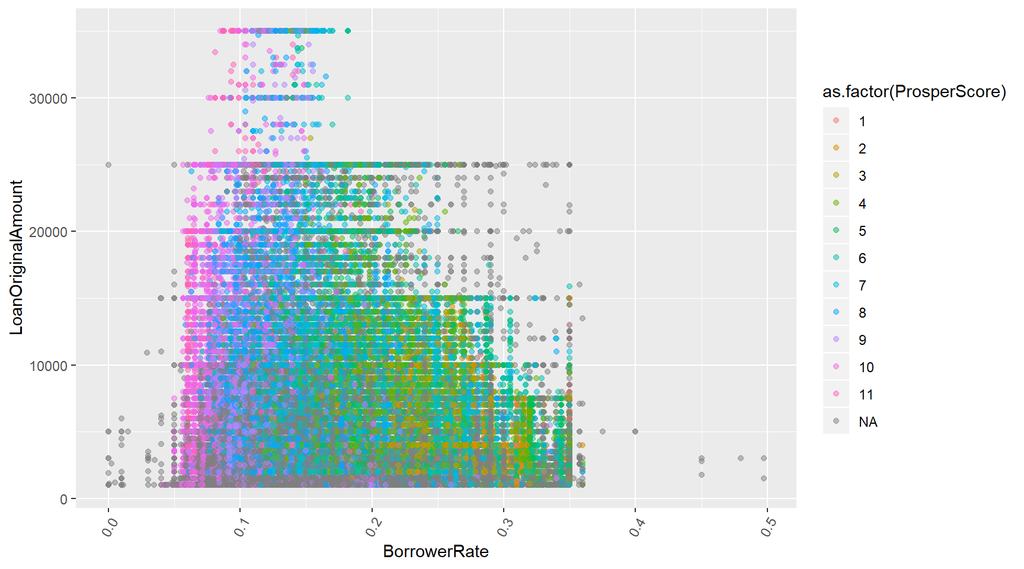

#### Multivariate Plot 2 - LoanOriginalAmount, StatedMonthlyIncome and LoanStatus

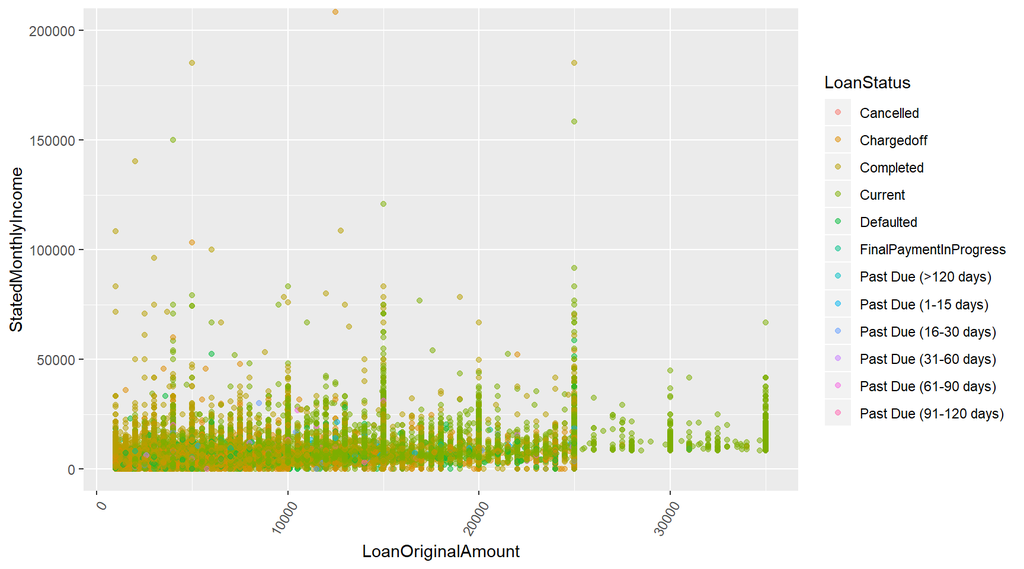

#### Multivariate Plot 3 - LoanOriginalAmount, StatedMonthlyIncome and IsBorrowerHomeowner

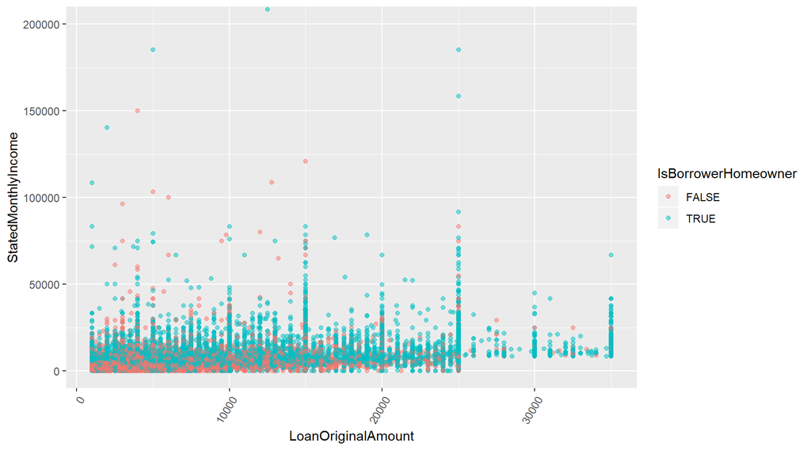

# Multivariate Analysis

### Were there any interesting or surprising interactions between features?

It can be observed that BorrowerRate and ProsperScore seem to be highly correlated. Additionally, Homeowners tend to be in a better financial position and that, perhaps, makes them better candidates for granting loans.

### OPTIONAL: Did you create any models with your dataset? Discuss the strengths and limitations of your model.

No, no models were created for this since this is focused as an EDA project. However, future editions may include statistical models such as a logistic regression model.